# Evaluating-data

Judy-Malas

12/23/2021

This workflow is based on the 2018_ASM_Workshop by Scott A. Handley

Here is the forked repository: https://github.com/jud-m/2018_ASM_Workshop.

In this workflow we will assess the data in our phyloseq objects and make sure it is ready for downstream visualization and statistics.

- Inputs:
  - ps_all
  - vst_all
  - ps_killed +vst_killed
- outputs:
  - ps_all.step2
  - vst_all.step2
  - ps_all.rl
  - ps_all.prop
  - ps_killed.step2
  - vst_killed.step2
  - ps_killed.rl
  - ps_killed.prop

### Load packages

```r
library(ggplot2)
library(gridExtra)
library(phyloseq)
require("tidyverse")
library("dplyr")
library("rmarkdown")
library("vegan")
library("PoiClaClu")
library("doParallel")
library("plotly")
library("microbiome")
library("ggpubr")
library("viridis")
library("plyr")
library("magrittr")
library("scales")
#library("data.table")
#library(grid)
#library(reshape2)
#library(randomForest)
```

## Load the input files

The input files for this part of the workflow are phyloseq objects such as those made in the `Making-phyloseq-objects` part of the workflow

```r
ps_all <- readRDS("~/landfill-microcosms/data/live_samples_objects/ps_all") # live samples
vst_all <- readRDS("~/landfill-microcosms/data/live_samples_objects/vst_all") # live samples with transformed count table
ps_killed <-readRDS("~/landfill-microcosms/data/killed_microcosms_objects/ps_killed") #killed samples
vst_killed <-readRDS("~/landfill-microcosms/data/killed_microcosms_objects/vst_killed") #killed samples with transformed count table
```

Make sure all of the files in the global environment are listed as “Large Phyloseq” (~2 MB or larger), if not, then your file didn’t save correctly in the previous workflow, go back and re-save it then re-load here. It’s possible that your file size will be smaller if you have fewer samples, but the most important thing is that when you open the object, you get the following:

```r
ps_all
```

```
## phyloseq-class experiment-level object
## otu_table()   OTU Table:         [ 1564 taxa and 83 samples ]
## sample_data() Sample Data:       [ 83 samples by 11 sample variables ]
## tax_table()   Taxonomy Table:    [ 1564 taxa by 7 taxonomic ranks ]
## phy_tree()    Phylogenetic Tree: [ 1564 tips and 1562 internal nodes ]
```

You should get a `phyloseq-class experiment-level object` with an `otu-table`, `sample_data`, `tax_table`, and `phy_tree()` (if a phylogentic tree was added)

#Tidying Data

## Factor re-ordering

```r
#ps_all
as.factor(sample_data(ps_all)$spike) #check the names of the levels
sample_data(ps_all)$spike <- factor(sample_data(ps_all)$spike, levels = c("Control ", "Antibiotics", "Fe(OH)3", "Na2SO4")) #ran into an issue because "Control " had a space at the end of it; R is senstive to spaces
levels(sample_data(ps_all)$spike) #check that your levels are in the order you want
sample_data(ps_all)$spike <- factor(sample_data(ps_all)$spike, labels = c("Control", "Antibiotics", "Fe(OH)3", "Na2SO4")) #remove the space
levels(sample_data(ps_all)$spike)

#repeat for all phyloseq objects

#vst_all
as.factor(sample_data(vst_all)$spike)
sample_data(vst_all)$spike <- factor(sample_data(ps_all)$spike, levels = c("Control ", "Antibiotics", "Fe(OH)3", "Na2SO4"))
sample_data(vst_all)$spike <- factor(sample_data(ps_all)$spike, labels = c("Control", "Antibiotics", "Fe(OH)3", "Na2SO4")) #remove the space
levels(sample_data(vst_all)$spike)

#ps_killed
as.factor(sample_data(ps_killed)$spike)
sample_data(ps_killed)$spike <- factor(sample_data(ps_killed)$spike, levels = c("killed_control", "Antibiotics","Fe(OH)3", "Na2SO4"))
levels(sample_data(ps_killed)$spike)

#vst_killed
as.factor(sample_data(vst_killed)$spike)
sample_data(ps_killed)$spike <- factor(sample_data(ps_killed)$spike, levels = c("killed_control", "Antibiotics","Fe(OH)3", "Na2SO4"))
levels(sample_data(ps_killed)$spike)
```

```r
newcolnames <- as.factor(c("Domain", "Phylum", "Class", "Order","Family" , "Genus",  "Species"))

colnames(tax_table(ps_all))  <- newcolnames

colnames(tax_table(ps_all))  #check that it worked
```

```
## [1] "Domain"  "Phylum"  "Class"   "Order"   "Family"  "Genus"   "Species"
```

```r
colnames(tax_table(vst_all)) <- newcolnames

colnames(tax_table(ps_killed)) <- newcolnames

colnames(tax_table(vst_killed)) <- newcolnames


colnames(tax_table(vst_all))
```

```
## [1] "Domain"  "Phylum"  "Class"   "Order"   "Family"  "Genus"   "Species"
```

```r
colnames(tax_table(ps_killed))
```

```
## [1] "Domain"  "Phylum"  "Class"   "Order"   "Family"  "Genus"   "Species"
```

```r
colnames(tax_table(vst_killed))
```

```
## [1] "Domain"  "Phylum"  "Class"   "Order"   "Family"  "Genus"   "Species"
```

# Evaluating Data

There are several possible ways to evaluate the data, but a standard approach consists of the following

- Step 1) Evaluate Amplicon Sequence Variants (ASV) summary statistics
- Step 2) Detect & remove outlier samples
- Step 3) Taxon cleaning
- Step 4) Prevalence assesment & filtering

## Step 1) Evaluate Amplicon Sequence Variants (ASVs)

This part is only really relevant for the non-transformed phyloseq objects. The variance stabilizing transformation somehow re-combines the data so the ASVs in each sample are no longer accurate

This chunk makes a data frame with 3 variables to count the number of ASVs in descreasing order

```r
readsumsdf.all <- data.frame(nreads = sort (taxa_sums(ps_all), decreasing = TRUE), # Create a new data frame of the sorted row sums,
                         sorted = 1:ntaxa(ps_all ), #a column of sorted values from 1 to the total number of individuals/counts for each ASV
                        type = "ASVs" #a categorical variable stating these are all ASVs.
                         )

readsumsdf.killed <- data.frame(nreads = sort (taxa_sums(ps_killed), decreasing = TRUE), # Create a new data frame of the sorted row sums,
                         sorted = 1:ntaxa(ps_killed), #a column of sorted values from 1 to the total number of individuals/counts for each ASV
                        type = "ASVs" #a categorical variable stating these are all ASVs.
                         )
```

```r
# Make a data frame with a column for the read counts of each sample for histogram production
sample_sum_df.all <- data.frame(sum = sample_sums(ps_all))

sample_sum_df.killed <- data.frame (sum = sample_sums(ps_killed))
```

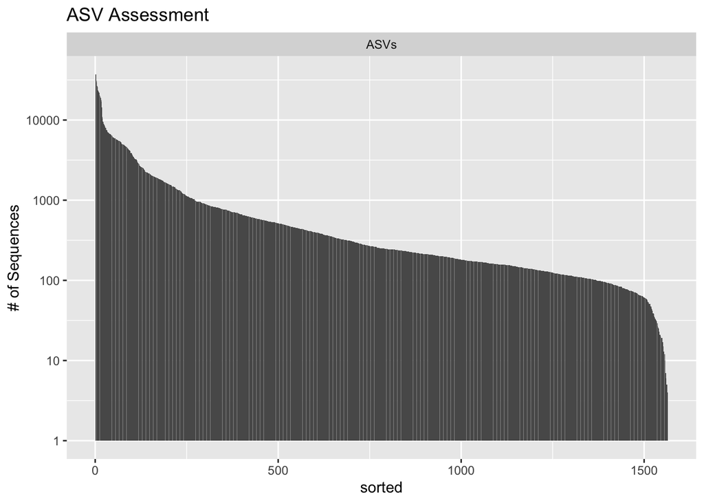

```r
# Generates a second bar plot with # of reads (y-axis) per sample. Sorted from most to least

ggplot(readsumsdf.all, aes(x = sorted, y = nreads)) +
  geom_bar(stat = "identity") +
  ggtitle("ASV Assessment") +
  scale_y_log10() +
  facet_wrap(~type, scales = "free") +
  ylab("# of Sequences")
```

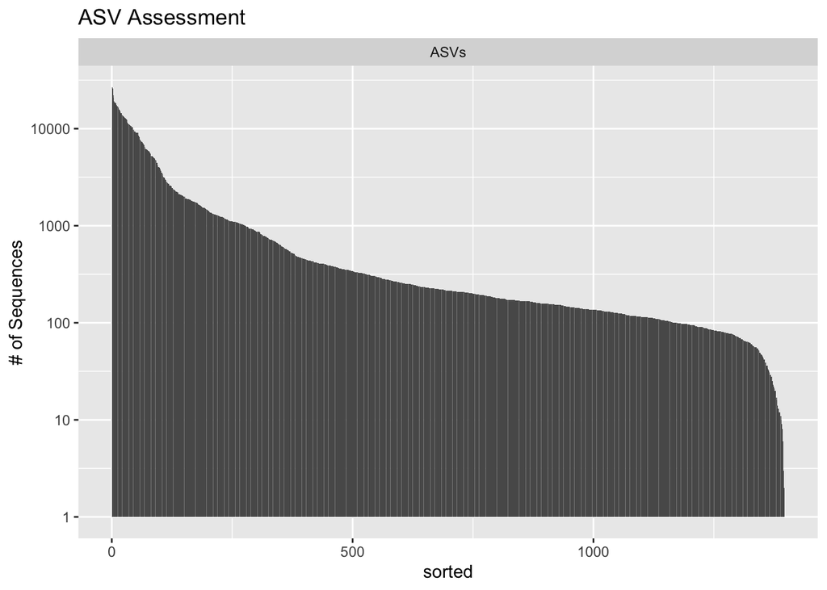

```r
ggplot(readsumsdf.killed, aes(x = sorted, y = nreads)) +
  geom_bar(stat = "identity") +
  ggtitle("ASV Assessment") +
  scale_y_log10() +
  facet_wrap(~type, scales = "free") +
  ylab("# of Sequences")
```

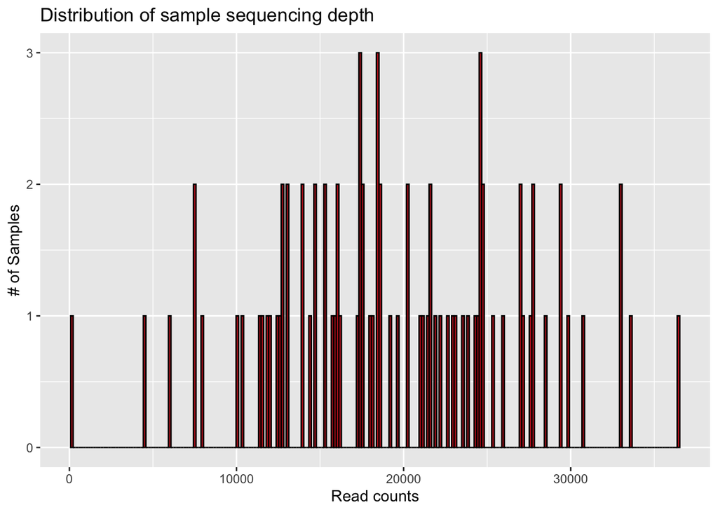

```r
# Histogram of the number of Samples (y-axis) at various read depths

ggplot(sample_sum_df.all, aes(x = sum)) +
  geom_histogram(color = "black", fill = "firebrick3", binwidth = 150) +
  ggtitle("Distribution of sample sequencing depth") +
  xlab("Read counts") +
  ylab("# of Samples")
```

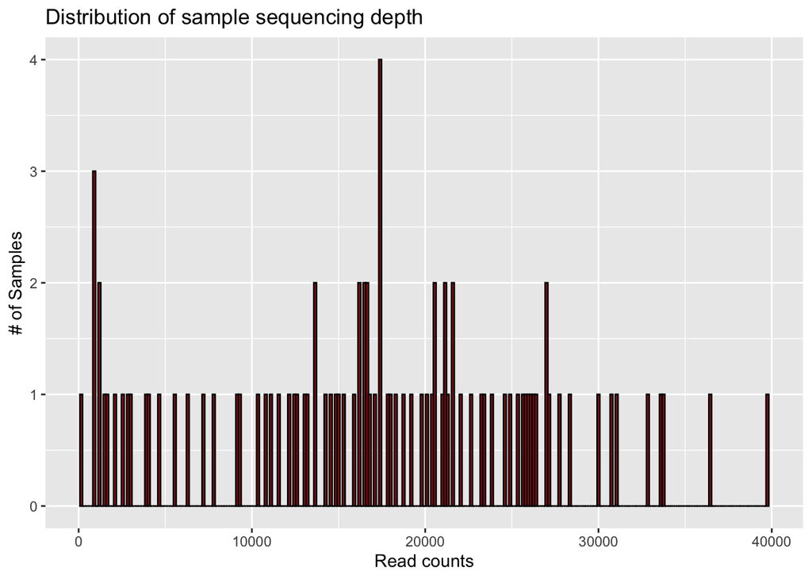

```r
ggplot(sample_sum_df.killed, aes(x = sum)) +
  geom_histogram(color = "black", fill = "firebrick3", binwidth = 150) +
  ggtitle("Distribution of sample sequencing depth") +
  xlab("Read counts") +
  ylab("# of Samples")
```

```r
summary(sample_sums(ps_all))
```

```
##    Min. 1st Qu.  Median    Mean 3rd Qu.    Max.
##      93   14530   18606   19414   24598   36383
```

```r
summary(sample_sums(ps_killed))
```

```
##    Min. 1st Qu.  Median    Mean 3rd Qu.    Max.
##      83   11038   17358   16952   23401   39735
```

The above data assessment is useful for getting an idea of

1. the number of sequences per taxa. This will normally be a “long tail” with some taxa being highly abundant in the data tapering off to taxa with very few reads,
2. the number of reads per sample.

Very low read count can be indicative of a failed reaction.

Both of these plots will help give an understanding of how your data are structured across taxa and samples and will vary depending on the nature of your samples.